# CHEP 898 Supervised Learning

Harsimran Ghai

2026-03-21

# Github link

https://github.com/harsimranghai91-eng/Supervised-Learning-CHEP-898.git

# Loading the Library

```r
library(tidyverse)
library(tidymodels)
```

```r
library(sjPlot)
library(C50)
library(ranger)
library(finalfit)
library(knitr)
library(gtsummary)
library(mlbench)
library(vip)
library(rsample)
library(rpart.plot)
library(tune)
library(recipes)
library(yardstick)
library(parsnip)
library(glmnet)
library(themis)
library(microbenchmark)
```

# Loading the Data

I used the Canpath Imputed dataset for this assignment.

```r
data <- read_csv("Canpath_imputed.csv")
```

# Simplifying the dataset

Extracting some of the relevant variables to make the dataset simple for ease of computation.

```r
Small_data <- select(data, DIS_CROHN_EVER, HS_GEN_HEALTH, SDC_AGE_CALC, SDC_EDU_LEVEL, PM_BMI_SR, WRK_FULL_TIME, SMK_CIG_EVER, SDC_INCOME, PA_TOTAL_SHORT, HS_ROUTINE_VISIT_EVER, PSE_ADULT_WRK_DURATION, DIS_RESP_SLEEP_APNEA_EVER, SDC_EDU_LEVEL_AGE, SDC_GENDER)
```

# Preparing the variables

The Crohn Disease was used as the outcome variable of interest. The variable was recoded to binary with 0 representing no crohn disease and 1 representing crohn disease.

```r
table(Small_data$DIS_CROHN_EVER)
```

```
##
##     0     1     2
## 38857   348  1982
```

```r
Small_data <- Small_data %>%
    mutate(Crohn = case_when(
        DIS_CROHN_EVER == 0 ~ "No",
        DIS_CROHN_EVER == 1 ~ "Yes",
        DIS_CROHN_EVER == 2 ~ "No")) %>%
        mutate(Crohn = as.factor(Crohn))

table(Small_data$DIS_CROHN_EVER, Small_data$Crohn)
```

```
##
##        No   Yes
##   0 38857     0
##   1     0   348
##   2  1982     0
```

```r
Small_data$DIS_CROHN_EVER <- NULL
```

The general health variable was recoded from 5 levels to 4 levels to make the sample even in each sample.

```r
table(Small_data$HS_GEN_HEALTH)
```

```
##
##     1     2     3     4     5
##   832  3377 12783 17183  7012
```

```r
# Merging the level 1 and level 2 to make the level close in sample size

Small_data <- Small_data %>%
    mutate(gen_health = case_when(
        HS_GEN_HEALTH == 1 ~ 1,
        HS_GEN_HEALTH == 2 ~ 1,
        HS_GEN_HEALTH == 3 ~ 2,
        HS_GEN_HEALTH == 4 ~ 3,
        HS_GEN_HEALTH == 5 ~ 4)) %>%
        mutate(gen_health = as.factor(gen_health))

table(Small_data$HS_GEN_HEALTH, Small_data$gen_health)
```

```
##
##         1     2     3     4
##   1   832     0     0     0
##   2  3377     0     0     0
##   3     0 12783     0     0
##   4     0     0 17183     0
##   5     0     0     0  7012
```

```r
Small_data$HS_GEN_HEALTH <- NULL
```

# Exploratory data Analysis

## Changing variables into factors

```r
Small_data <- Small_data %>% mutate(across(c(SDC_EDU_LEVEL,WRK_FULL_TIME, SMK_CIG_EVER, SDC_INCOME, HS_ROUTINE_VISIT_EVER, DIS_RESP_SLEEP_APNEA_EVER,SDC_GENDER),as.factor))
```

## Descriptive of dataset

```r
summary(Small_data)
```

```
##   SDC_AGE_CALC   SDC_EDU_LEVEL     PM_BMI_SR     WRK_FULL_TIME SMK_CIG_EVER
##  Min.   :30.00   6      :11010   Min.   : 8.86   0:18880       0:22255
##  1st Qu.:43.00   4      :10175   1st Qu.:23.41   1:22307       1:18932
##  Median :52.00   2      : 7809   Median :26.62
##  Mean   :51.48   7      : 6268   Mean   :27.66
##  3rd Qu.:60.00   3      : 3486   3rd Qu.:30.68
##  Max.   :74.00   5      : 1795   Max.   :69.40
##                  (Other):  644
##    SDC_INCOME   PA_TOTAL_SHORT  HS_ROUTINE_VISIT_EVER PSE_ADULT_WRK_DURATION
##  6      :8826   Min.   :    0   0:  536               Min.   : 0.000
##  4      :8008   1st Qu.:  600   1:40651               1st Qu.: 0.000
##  5      :7667   Median : 1800                         Median : 2.000
##  3      :6815   Mean   : 2606                         Mean   : 6.687
##  7      :3965   3rd Qu.: 3795                         3rd Qu.:10.000
##  8      :2885   Max.   :19278                         Max.   :51.000
##  (Other):3021
##  DIS_RESP_SLEEP_APNEA_EVER SDC_EDU_LEVEL_AGE SDC_GENDER Crohn       gen_health
##  0:35355                   Min.   :-7.00     1:15200    No :40839   1: 4209
##  1: 3916                   1st Qu.:19.00     2:25987    Yes:  348   2:12783
##  2: 1916                   Median :23.00                            3:17183
##                            Mean   :25.34                            4: 7012
##                            3rd Qu.:28.00
##                            Max.   :73.00
##
```

## Checking Duplicates

```r
duplicated(Small_data)
```

[output not shown]

[output cut: 3418 more lines]

No Duplicated values were found in this dataset.

## Checking the missing values

```r
any(is.na(Small_data))
```

```
## [1] FALSE
```

No missing values were found in the dataset as expected from imputed dataset.

# Splitting the dataset

```r
# Fixing the random numbers by setting the seed to reproduce the analysis
set.seed(10)

# Cross Validation Split
cv_split <- initial_validation_split(Small_data,
                            strata = Crohn,
                            prop = c(0.70, 0.20))

# Create data frames for the two sets:
train_data <- training(cv_split)
table(train_data$Crohn)
```

```
##
##    No   Yes
## 28587   243
```

```r
test_data  <- testing(cv_split)
table(test_data$Crohn)
```

```
##
##   No  Yes
## 4084   35
```

# Model Building

## Setting the core

```r
cores <- parallel::detectCores()
cores
```

```
## [1] 10
```

```r
rf_model <- rand_forest(mtry = tune(), min_n = tune(), trees = 100) %>%
              set_engine("ranger", num.threads = cores) %>%
              set_mode("classification")
```

## Creating a Recipe

```r
Health_recipe <-
  recipe(Crohn ~ ., data = train_data) %>%
  step_zv(all_predictors())
```

## Creating a Workflow

```r
Health_workflow <-
        workflow() %>%
        add_model(rf_model) %>%
        add_recipe(Health_recipe)

Health_workflow
```

```
## ══ Workflow ════════════════════════════════════════════════════════════════════
## Preprocessor: Recipe
## Model: rand_forest()
##
## ── Preprocessor ────────────────────────────────────────────────────────────────
## 1 Recipe Step
##
## • step_zv()
##
## ── Model ───────────────────────────────────────────────────────────────────────
## Random Forest Model Specification (classification)
##
## Main Arguments:
##   mtry = tune()
##   trees = 100
##   min_n = tune()
##
## Engine-Specific Arguments:
##   num.threads = cores
##
## Computational engine: ranger
```

## Fitting the Model

### Hyperparameter Tuning

```r
set.seed(100)

folds <- vfold_cv(train_data, v = 10)

rf_grid <- grid_regular(
              mtry(range = c(2, 13)),
              min_n(range = c(5, 50)),
              levels = 5
            )

rf_grid
```

```
## # A tibble: 25 × 2
##     mtry min_n
##    <int> <int>
##  1     2     5
##  2     4     5
##  3     7     5
##  4    10     5
##  5    13     5
##  6     2    16
##  7     4    16
##  8     7    16
##  9    10    16
## 10    13    16
## # ℹ 15 more rows
```

```r
Health_fit <- tune_grid(
                Health_workflow,
                resamples = folds,
                grid = rf_grid,
                control = control_resamples(save_pred = TRUE,
                                                  verbose = FALSE))

Health_fit
```

```
## # Tuning results
## # 10-fold cross-validation
## # A tibble: 10 × 5
##    splits               id     .metrics          .notes           .predictions
##    <list>               <chr>  <list>            <list>           <list>
##  1 <split [25947/2883]> Fold01 <tibble [75 × 6]> <tibble [0 × 4]> <tibble>
##  2 <split [25947/2883]> Fold02 <tibble [75 × 6]> <tibble [0 × 4]> <tibble>
##  3 <split [25947/2883]> Fold03 <tibble [75 × 6]> <tibble [0 × 4]> <tibble>
##  4 <split [25947/2883]> Fold04 <tibble [75 × 6]> <tibble [0 × 4]> <tibble>
##  5 <split [25947/2883]> Fold05 <tibble [75 × 6]> <tibble [0 × 4]> <tibble>
##  6 <split [25947/2883]> Fold06 <tibble [75 × 6]> <tibble [0 × 4]> <tibble>
##  7 <split [25947/2883]> Fold07 <tibble [75 × 6]> <tibble [0 × 4]> <tibble>
##  8 <split [25947/2883]> Fold08 <tibble [75 × 6]> <tibble [0 × 4]> <tibble>
##  9 <split [25947/2883]> Fold09 <tibble [75 × 6]> <tibble [0 × 4]> <tibble>
## 10 <split [25947/2883]> Fold10 <tibble [75 × 6]> <tibble [0 × 4]> <tibble>
```

### Plotting of the results.

#### Method 1

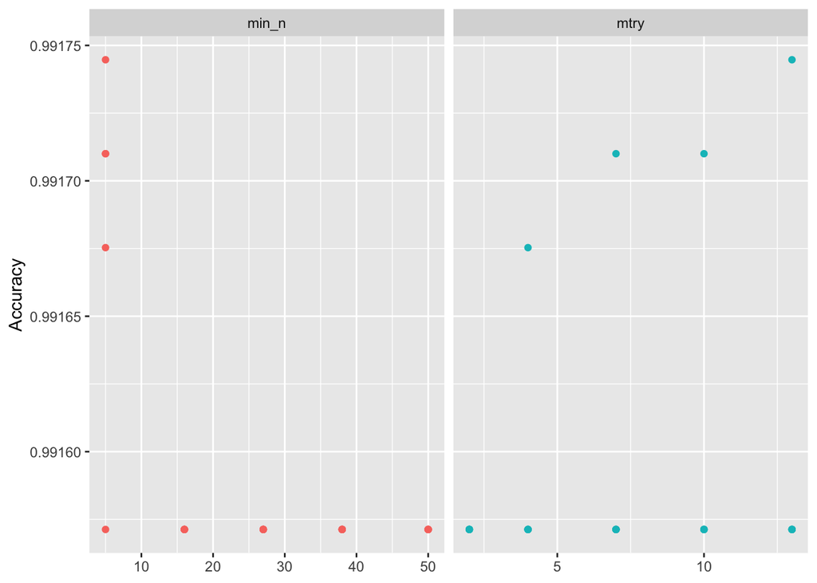

```r
Health_fit %>%
  collect_metrics() %>%
  filter(.metric == "accuracy") %>%
  select(mean, min_n, mtry) %>%
  pivot_longer(min_n:mtry,
    values_to = "value",
    names_to = "parameter"
  ) %>%
  ggplot(aes(value, mean, color = parameter)) +
  geom_point(show.legend = FALSE) +
  facet_wrap(~parameter, scales = "free_x") +
  labs(x = NULL, y = "Accuracy")
```

#### Method 2

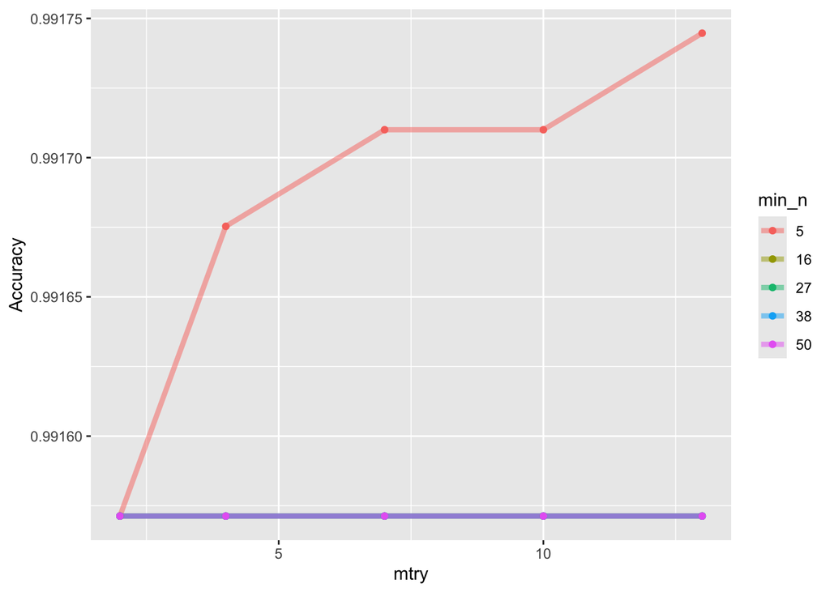

```r
Health_fit %>%
  collect_metrics() %>%
  filter(.metric == "accuracy") %>%
  mutate(min_n = factor(min_n)) %>%
  ggplot(aes(mtry, mean, color = min_n)) +
  geom_line(alpha = 0.5, size = 1.5) +
  geom_point() +
  labs(y = "Accuracy")
```

### Collecting the results

```r
rf_best <-
  Health_fit %>%
  select_best(metric = "accuracy")

rf_best
```

```
## # A tibble: 1 × 3
##    mtry min_n .config
##   <int> <int> <chr>
## 1    13     5 pre0_mod21_post0
```

```r
rf_auc_fit <-
  Health_fit %>%
  collect_predictions(parameters = rf_best)
```

### Metrics

#### Confusion Matrix

```r
conf_mat(rf_auc_fit, truth = Crohn,
         estimate = .pred_class)
```

```
##           Truth
## Prediction    No   Yes
##        No  28586   237
##        Yes     1     6
```

The model correctly classified people with no crohn disease, but is underperforming to predict those who has crohn disease. OUt of people with no crohn disease(N= 28587), the model correctly classified 28586. However, out of 243 people with crohn disease, the model only classified 6 as having crohn disease, showing significant underperformance.

#### Accuracy

```r
accuracy(rf_auc_fit, truth = Crohn,
         estimate = .pred_class, event_level= "second")
```

```
## # A tibble: 1 × 3
##   .metric  .estimator .estimate
##   <chr>    <chr>          <dbl>
## 1 accuracy binary         0.992
```

The accuracy of the model is 99.17, which even though is good but somewhat misleading given the model underperformance for people with crohn disease.

#### Sensitivity

```r
sens(rf_auc_fit, truth = Crohn,
         estimate = .pred_class, event_level= "second")
```

```
## # A tibble: 1 × 3
##   .metric .estimator .estimate
##   <chr>   <chr>          <dbl>
## 1 sens    binary        0.0247
```

The sensitivity of the model is only 2.5 % which is very low.

#### Specificity

```r
spec(rf_auc_fit, truth = Crohn,
         estimate = .pred_class, event_level= "second")
```

```
## # A tibble: 1 × 3
##   .metric .estimator .estimate
##   <chr>   <chr>          <dbl>
## 1 spec    binary         1.000
```

The specificity of the model is 99.99 % which is good.

#### F1 score

```r
f_meas(rf_auc_fit, truth = Crohn,
         estimate = .pred_class, event_level= "second")
```

```
## # A tibble: 1 × 3
##   .metric .estimator .estimate
##   <chr>   <chr>          <dbl>
## 1 f_meas  binary         0.048
```

The F1 score is low, which is 4.8%. This means that the model is failing to correctly identify positive cases.

## Baseline model

### Building the model

```r
rf_baseline <- rand_forest(
  trees = 100,
  mtry = NULL,
  min_n = NULL
) %>%
  set_engine("ranger") %>%
  set_mode("classification")
```

```r
Baseline_res <- fit_resamples(
  rf_baseline,
  Crohn ~ .,
  resamples = folds,
  control=control_resamples(save_pred = TRUE)
)
```

### Collecting the Results

```r
collect_metrics(Baseline_res)
```

```
## # A tibble: 3 × 6
##   .metric     .estimator    mean     n  std_err .config
##   <chr>       <chr>        <dbl> <int>    <dbl> <chr>
## 1 accuracy    binary     0.992      10 0.000644 pre0_mod0_post0
## 2 brier_class binary     0.00828    10 0.000615 pre0_mod0_post0
## 3 roc_auc     binary     0.632      10 0.0196   pre0_mod0_post0
```

```r
preds <- collect_predictions(Baseline_res)
```

### Metrics

#### Confusion Matrix of baseline model

```r
conf_mat(preds, truth = Crohn,
         estimate = .pred_class)
```

```
##           Truth
## Prediction    No   Yes
##        No  28587   243
##        Yes     0     0
```

The model correctly classified people with no crohn disease, but is underperforming to predict those who has crohn disease. Out of people with no crohn disease(N= 28587), the model correctly classified 28587. However, out of 243 people with crohn disease, the model didn’t classify any of them as positive, showing significant underperformance.

#### Accuracy of baseline model

```r
accuracy(preds, truth = Crohn,
         estimate = .pred_class, event_level="second")
```

```
## # A tibble: 1 × 3
##   .metric  .estimator .estimate
##   <chr>    <chr>          <dbl>
## 1 accuracy binary         0.992
```

The accurarcy of the model is 99.15% which as we know is misleading given the model didn’t classifies anyone as having the crohn disease.

#### Sensitivity of baseline model

```r
sens(preds, truth = Crohn,
         estimate = .pred_class,event_level= "second")
```

```
## # A tibble: 1 × 3
##   .metric .estimator .estimate
##   <chr>   <chr>          <dbl>
## 1 sens    binary             0
```

The sensitivity of the model is zero.

#### Specificity of baseline model

```r
spec(preds, truth = Crohn,
         estimate = .pred_class, event_level= "second")
```

```
## # A tibble: 1 × 3
##   .metric .estimator .estimate
##   <chr>   <chr>          <dbl>
## 1 spec    binary             1
```

The specificity of the model is one.

#### F1 score of baseline model

```r
f_meas(preds, truth = Crohn,
         estimate = .pred_class, event_level= "second")
```

```
## # A tibble: 1 × 3
##   .metric .estimator .estimate
##   <chr>   <chr>          <dbl>
## 1 f_meas  binary            NA
```

# Comparing the model

Based on the comparison of the model using the different metrics, we can say that the best model extracted using the hyperparameter tuning is better than the baseline model, even though the best model is also underperforming to predict crohn disease. This indicates that better predictor variables are required and even upsampling can also help in increasing the model performance due to uneven success to failure ratio.

# Final Model

```r
final_model <- finalize_model(
                  rf_model,
                  rf_best
                )

final_model
```

```
## Random Forest Model Specification (classification)
##
## Main Arguments:
##   mtry = 13
##   trees = 100
##   min_n = 5
##
## Engine-Specific Arguments:
##   num.threads = cores
##
## Computational engine: ranger
```

# Variable Importance

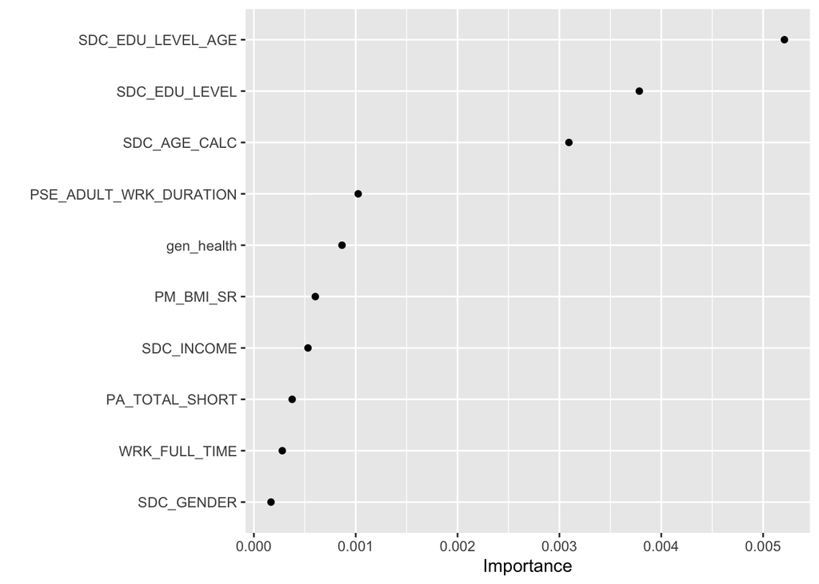

```r
tree_prep <- prep(Health_recipe)

final_model %>%
  set_engine("ranger", importance = "permutation") %>%
  fit(Crohn ~ .,
    data = juice(tree_prep)) %>%
  vip(geom = "point")
```

```r
final_rf_workflow <- workflow() %>%
                      add_recipe(Health_recipe) %>%
                      add_model(final_model)

final_results <- final_rf_workflow %>%
                    last_fit(cv_split)

final_results %>%
  collect_metrics()
```

```
## # A tibble: 3 × 4
##   .metric     .estimator .estimate .config
##   <chr>       <chr>          <dbl> <chr>
## 1 accuracy    binary       0.992   pre0_mod0_post0
## 2 roc_auc     binary       0.564   pre0_mod0_post0
## 3 brier_class binary       0.00883 pre0_mod0_post0
```